# Steelhead Overshoot Update

4/7/2022

## Changes to model

## Expanding the number of states

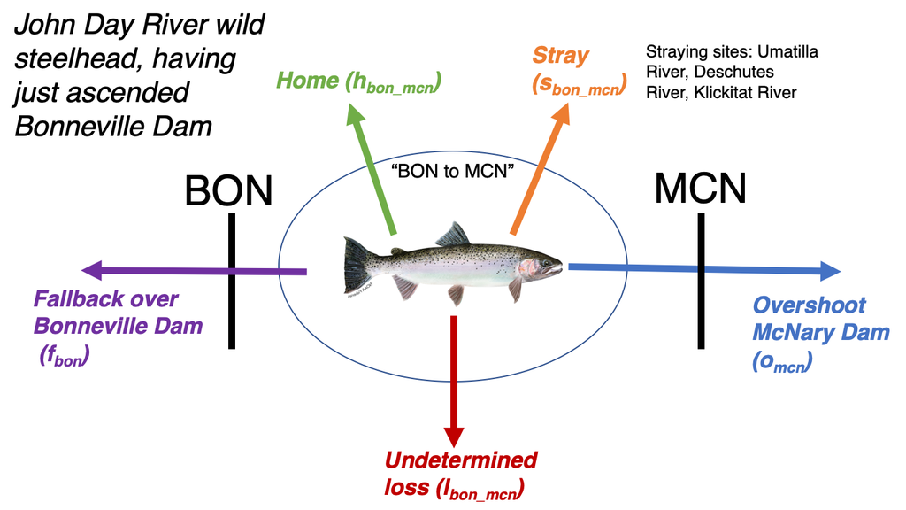

## Expanding the number of states

An individual in the BON to MCN state now has these movement options:

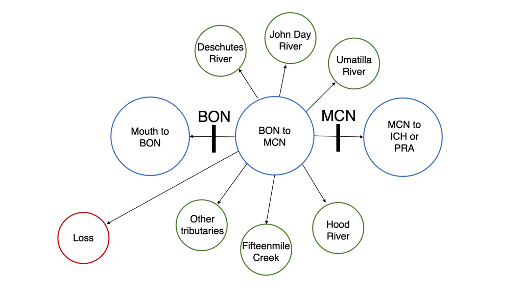

## Previous approach: Multinomial likelihood

- Get a vector of probabilities *p* with length *K*, where *K* is the number of unique observed detection histories
- In the John Day River dataset, *K* = 169 (169 unique detection histories)
- Example:

\[ \begin{aligned} n_{7} = f_{bon} * o_{bon} * f_{bon} * o_{bon} * h_{bon\_mcn} * l_{nat\_trib} \\ p[7] = n_{7} \end{aligned} \]

## Previous approach: Multinomial likelihood

```r
p <- c(n1, n2, n3, ... n169)

# Evaluate counts, where y are the counts of
# the number of times each of the unique detection
# histories was observed

# 2121 are the number of fish
y[1:N] ~ dmulti(p[1:N], 2121)
```

## Multinomial likelihood no longer works with covariates

For fish *i* at location *l* at time *t*: \[ \begin{aligned} \small \psi_{12}= f(temperature_{l,t}, origin_{i}) \end{aligned} \]

- Each movement probability is different for each individual fish, depending on the unique combination of covariates that it is experiencing
- Therefore, a multinomial likelihood, or using an m-array approach to summarize detection histories, becomes untenable, or at least very complicated

## Moving to an individual-based model

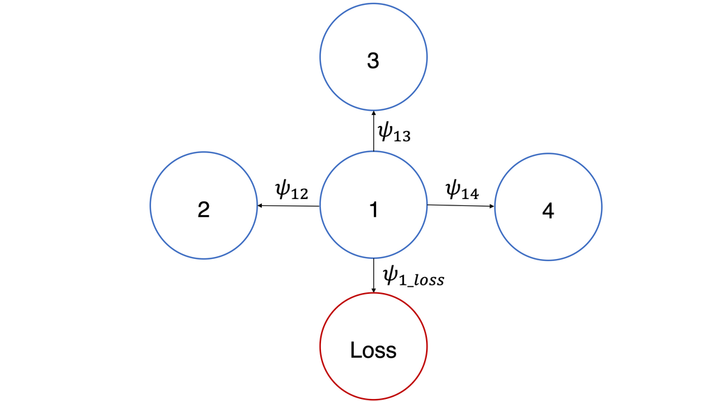

## Moving to an individual-based model

```r
for(i in 1:n.ind){ # Loop through all individuals
  for(j in 1:n.encounters){ # Loop through the encounters (detections)
    psi_12 <- f(origin[i], temperature[j])
    psi_13 <- f(origin[i], temperature[j])
    psi_14 <- f(origin[i], temperature[j])
    psi_1_loss <- 1 - psi_12 - psi_13 - psi_14

    # Likelihood: evaluate multinomial with single trial (categorical)

    # Get a vector of probabilities
    p <- c(psi_12, psi_13, psi_14, psi_1_loss)

    # y is an array, with dimensions (number of fish) X
    # (number of possible states) X (number of encounters)

    # y[i,,j] is the vector containing all possible next states for a fish
    y[i,,j] ~ dmulti(p, 1)
  }
}
```

## Example: y[i, , ] matrix

```
##                             [,1] [,2] [,3] [,4] [,5]
## mainstem, mouth to BON         0    0    0    0    0
## mainstem, BON to MCN           1    0    1    0    0
## mainstem, MCN to ICH or PRA    0    1    0    0    0
## mainstem, PRA to RIS           0    0    0    0    0
## mainstem, RIS to RRE           0    0    0    0    0
## mainstem, RRE to WEL           0    0    0    0    0
## mainstem, upstream of WEL      0    0    0    0    0
## mainstem, ICH to LGR           0    0    0    0    0
## mainstem, upstream of LGR      0    0    0    0    0
## Asotin Creek                   0    0    0    0    0
## Clearwater River               0    0    0    0    0
## Deschutes River                0    0    0    0    0
## Entiat River                   0    0    0    0    0
## Fifteenmile Creek              0    0    0    0    0
## Grande Ronde River             0    0    0    0    0
## Imnaha River                   0    0    0    0    0
## John Day River                 0    0    0    1    0
## loss                           0    0    0    0    1
```

## Including covariates

- Enforcing sum to 1 constraint with covariates via the multinomial logit

\[ \begin{aligned} \small \psi_{12}= \frac{\exp(\beta_{0,12} + \beta_{temp,12} * temp + \beta_{origin,12}[origin])}{1 + \exp(\beta_{0,12} + \beta_{temp,12} * temp + \beta_{origin,12}[origin]) + \\ \exp(\beta_{0,13} + \beta_{temp,13} * temp + \beta_{origin,13}[origin]) + \\ \exp(\beta_{0,14} + \beta_{temp,14} * temp + \beta_{origin,14}[origin])} \\ \end{aligned} \]

## Detection probabilities - auxiliary likelihoods?

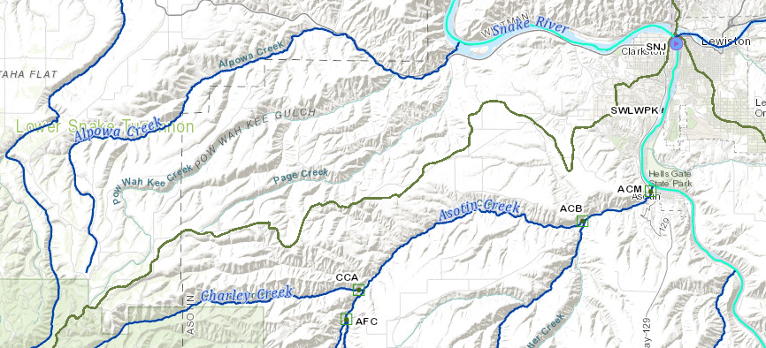

## New approach to covariate time window

## Old approach and issues:

- Old approach: Determine the median travel time from one dam to the next dam for each month and each natal origin; get the average value of the variable (e.g., temperature) for the weeklong window around that time
- This works well for upstream travel, but with downstream travel, we don’t typically know when individuals entered states because of the low detection probability with downstream travel

## Old approach and issues:

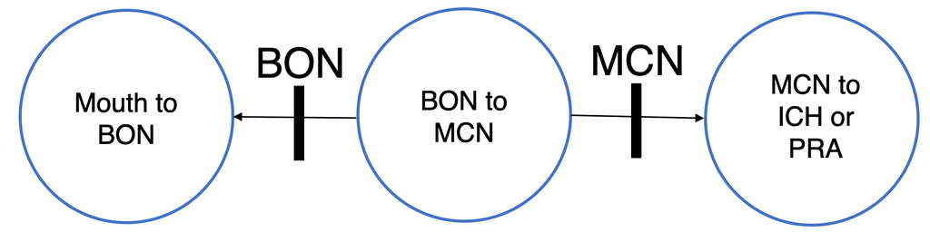

- Our state-based model also doesn’t assume the direction a fish is traveling when in a given state, so calculating a median travel time (either upstream or downstream) is problematic

## New approach:

- Calculate an “experience date”, from the time at arrival in state 1 and the time at arrival at state 2, which are typically known (e.g., the date + time that an individual was seen in the adult fish ladder at a dam)
- Calculate the time spent in this state as (time at arrival in state 2) - (time at arrival in state 1)
- Get the “experience date” by dividing the time spent in the state by 2 (this is equivalent to the median time in the state)

```
##               state     pathway arrival_date   exp_date
## 1        BON to MCN BON (adult)   2010-07-24 2010-08-23
## 2 MCN to ICH or PRA MCN (adult)   2010-09-22       <NA>
```

## New approach:

- If the arrival time in a state is not known (i.e., the site visit was implicit), then take the halfway point between two known site arrivals as the arrival time in the implicit state
- If there were N implicit site visits between known arrival times, divide the time between the two known arrival times by N+1 to estimate the time spent in each state

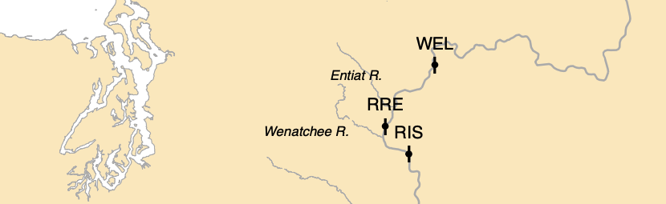

```
##             state           date_time     pathway   date_source arrival_date
## 1      RRE to WEL 2011-05-03 09:23:37 RRE (adult) known_arrival   2011-05-03
## 2      RIS to RRE                <NA>    implicit  interpolated   2011-05-07
## 3 Wenatchee River 2011-05-11 04:09:47   WEN_sites known_arrival   2011-05-11
```

## New approach: Example detection history

```
##               state             pathway arrival_date   exp_date
## 1        BON to MCN         BON (adult)   2010-07-24 2010-08-23
## 2 MCN to ICH or PRA         MCN (adult)   2010-09-22 2010-09-25
## 3        PRA to RIS         PRA (adult)   2010-09-28 2010-09-30
## 4        RIS to RRE         RIS (adult)   2010-10-02 2011-01-09
## 5        RRE to WEL         RRE (adult)   2011-04-18 2011-04-22
## 6        RIS to RRE RRE_fallback_arrays   2011-04-27 2011-04-30
## 7        RRE to WEL         RRE (adult)   2011-05-03 2011-05-05
## 8        RIS to RRE            implicit   2011-05-07 2011-05-09
## 9   Wenatchee River           WEN_sites   2011-05-11 2011-05-11
```

## Indexing to covariate by state (location) and “experience date”

```
##        state             pathway arrival_date   exp_date
## 5 RRE to WEL         RRE (adult)   2011-04-18 2011-04-22
## 6 RIS to RRE RRE_fallback_arrays   2011-04-27 2011-04-30
```

```
##         date ICH.to.LGR BON.to.MCN PRA.to.RIS RIS.to.RRE RRE.to.WEL
## 1 2011-04-22     8.4292     8.0042     6.4667     6.3833     6.3043
## 2 2011-04-23     8.5250     8.1417     6.5750     6.4042     6.4333
## 3 2011-04-24     8.8083     8.2917     6.6292     6.5292     6.6417
## 4 2011-04-25     8.8750     8.5125     6.7875     6.6875     6.7667
## 5 2011-04-26     9.0458     8.6417     6.9000     6.7958     6.8417
## 6 2011-04-27     9.3375     8.6833     6.9542     6.9083     6.9083
## 7 2011-04-28     9.5792     8.7500     7.1478     7.0261     6.9909
## 8 2011-04-29     9.6583     8.7708     7.2042     7.0792     7.0542
## 9 2011-04-30     9.6083     8.7417     7.2125     6.2500     6.9417
```

## Problem: What to do at branching states?

MCN to PRA or ICH

- Two dams with covariate data at this state: PRA tailrace and ICH tailrace
- Potential solution could be to include the covariates (temperature, spill, flow) at both dams as covariates for just this state
- Could have temperature at PRA tailrace be covariate for ascending PRA, and temperature at ICH tailrace be covariate for ascending ICH

## New potential covariate: time in a state

For individuals who are in the “mainstem, BON to MCN” state, how long does it take them to reach the next state?

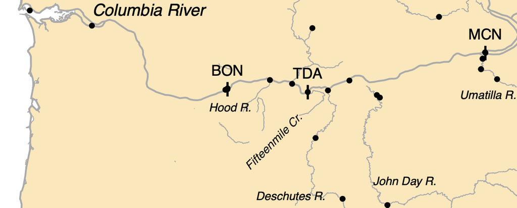

## Time in a state: directionality issue

### Individuals in BON to MCN state who just ascended BON

```
## # A tibble: 8 × 2
##   next_state                   `median time (days)`
##   <chr>                                       <dbl>
## 1 Umatilla River                              126.
## 2 John Day River                               79.5
## 3 BON to MCN other tributaries                 21
## 4 mainstem, MCN to ICH or PRA                  14
## 5 Deschutes River                               7
## 6 Fifteenmile Creek                             7
## 7 Hood River                                    4
## 8 mainstem, mouth to BON                        0
```

## Time in a state: directionality issue

### Individuals in BON to MCN state who did not just ascend BON

```
## # A tibble: 6 × 2
##   next_state                   `median time (days)`
##   <chr>                                       <dbl>
## 1 John Day River                               64
## 2 BON to MCN other tributaries                 62
## 3 Umatilla River                               51
## 4 mainstem, mouth to BON                       46
## 5 Deschutes River                               5.5
## 6 mainstem, MCN to ICH or PRA                   1
```

Note: no individuals entered Hood River or Fifteenmile Creek next

## Missing covariate data

- How do we handle missing covariate data?
- Does missing covariate data indicate no flow?

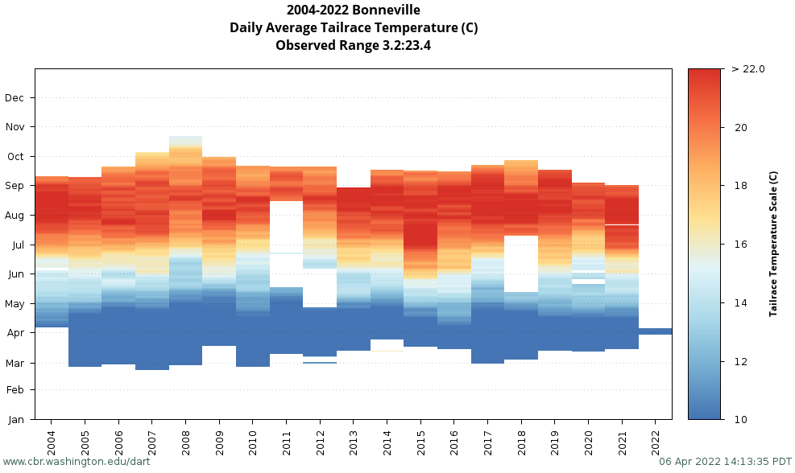